# Dictionary methods

Constantine Boussalis

10 February 2022

In this tutorial we will use the built-in Lexicoder Sentiment Dictionary (Young & Soroka, 2012) to study sentiment in a corpus of North Korean news articles from 2015. You can find this dataset (`kcna_example2015.csv`) in the `_Data` directory in the course folder.

First let’s bring in our corpus and do some very basic preprocessing. We will not stem the terms so as to facilitate matching with the dictionary. The code ends with the creation of a document-feature matrix.

```r
library(quanteda)
library(dplyr)
library(lubridate)
library(readtext) # for importing external corpus data

# Read in csv file with readtext. Note this address will be different for your system.
kcna_csv <- readtext("./data/kcna_example2015.csv",
                     encoding = "utf-8",
                     text_field = "newsText") # the column with the header "newsText" in the csv contains the article text.

# Generate datetimes
kcna_csv$date <- dmy(kcna_csv$newsDate)
kcna_csv$week <- week(kcna_csv$date)

# Create a quanteda corpus using the imported data
corpus_kcna <- corpus(kcna_csv)

# Create a dfm object with processed text
kcna_dfm <- corpus_kcna %>%
  quanteda::tokens(remove_numbers = TRUE,
                   remove_punct = TRUE,
                   remove_symbols = TRUE,
                   remove_hyphens = TRUE,
                   remove_separators = TRUE,
                   remove_url = TRUE,
                   include_docvars = TRUE) %>%
  dfm()
```

We will be using the LSD in **quanteda**. Here is a peek:

```r
sample(data_dictionary_LSD2015$negative, 10) # sample of 10 negative words
```

```
##  [1] "execrat*"  "suffocat*" "crying"    "crude*"    "bury*"     "dolour*"
##  [7] "demolish*" "scuffl*"   "traps"     "worse*"
```

```r
sample(data_dictionary_LSD2015$positive, 10) # sample of 10 positive words
```

```
##  [1] "dexter*"       "one of a kind" "prize*"        "tolera*"
##  [5] "powerful*"     "comforts*"     "entranced"     "impeccable*"
##  [9] "enchant*"      "cooperat*"
```

The LSD also has “neg_positive” and “neg_negative” keys that include negations. For now, we will ignore these keys and just focus on negative and positive. We can create a dfm object of dictionary words that match our corpus.

```r
kcna_sent_dfm <- dfm_lookup(kcna_dfm,
                     dictionary = data_dictionary_LSD2015[1:2])

head(kcna_sent_dfm, 5)
```

```
## Document-feature matrix of: 5 documents, 2 features (10.00% sparse) and 7 docvars.
##                         features
## docs                     negative positive
##   kcna_example2015.csv.1        2        1
##   kcna_example2015.csv.2      155      447
##   kcna_example2015.csv.3        0        9
##   kcna_example2015.csv.4       10       56
##   kcna_example2015.csv.5        1        5
```

As we can see, there are differences within documents in terms of negative and positive sentiment matches. Importantly, it seems that document length also varies significantly. Let’s normalize the sentiment scores by total words and then calculate the difference between positive and negative proportion of words.

```r
docvars(kcna_dfm, "prop_negative") <- as.numeric(kcna_sent_dfm[,1] / ntoken(kcna_dfm)) # add proportion of negative words to original dfm
docvars(kcna_dfm, "prop_positive") <- as.numeric(kcna_sent_dfm[,2] / ntoken(kcna_dfm))
docvars(kcna_dfm, "net_sentiment") <- docvars(kcna_dfm, "prop_positive") - docvars(kcna_dfm, "prop_negative") # calculate net sentiment
```

How did net sentiment vary over time for all articles?

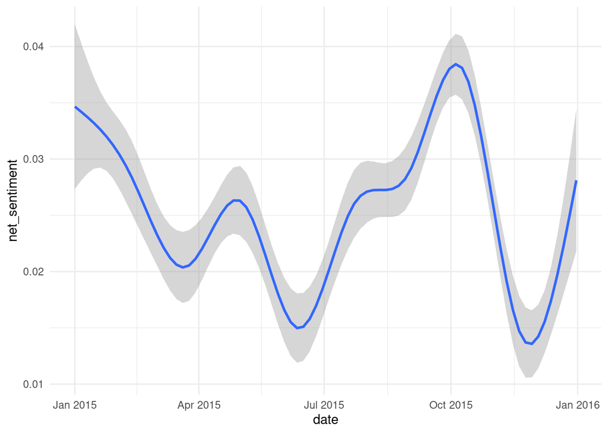

```r
library(ggplot2)
kcna_sent_plot <- ggplot(docvars(kcna_dfm),
                         aes(x = date,
                             y = net_sentiment)) +
  geom_smooth() +
  theme_minimal()
kcna_sent_plot
```

As is typical, there is a predominant postivity bias.

Which are the most positive and most negative news articles? Let’s add the netsentiment score to the original dataframe.

```r
kcna_csv$net_sentiment <- as.numeric(kcna_dfm@docvars$net_sentiment)
```

Most positive news article:

```r
most_postive <- kcna_csv[which.max(kcna_csv$net_sentiment),]
most_postive$text
```

```
## [1] "Kim Jong Il's Patriotism Introduced by Peruvian Paper The June issue of the Peruvian paper Accion Nacionalista carried an article titled 'Kim Jong Il's patriotism' illustrated with his photo.The article said that leader Kim Jong Il was a peerless patriot.His patriotism was the most honest an…
```

Most negative news article:

```r
most_negative <- kcna_csv[which.min(kcna_csv$net_sentiment),]
most_negative$text
```

```
## [1] "  An old man in his seventies infected with epidemic spread by wild tick died on Jeju Island on June 14, according to MBC of south Korea. The epidemic occurred in South Chungchong Province, south Korea in May, too.  55 people were infected with the epidemic last year and 15 of them died."
```

### Targeted dictionary analysis

How about a more targeted analysis, say the sentiment of words around the term “nuclear”? We can use the `tokens_select` and `window` argument to perform this targeted dictionary analysis. First, we will construct a tokens object from the original corpus object. Then the documents will become a window of terms +/- 15 tokens.

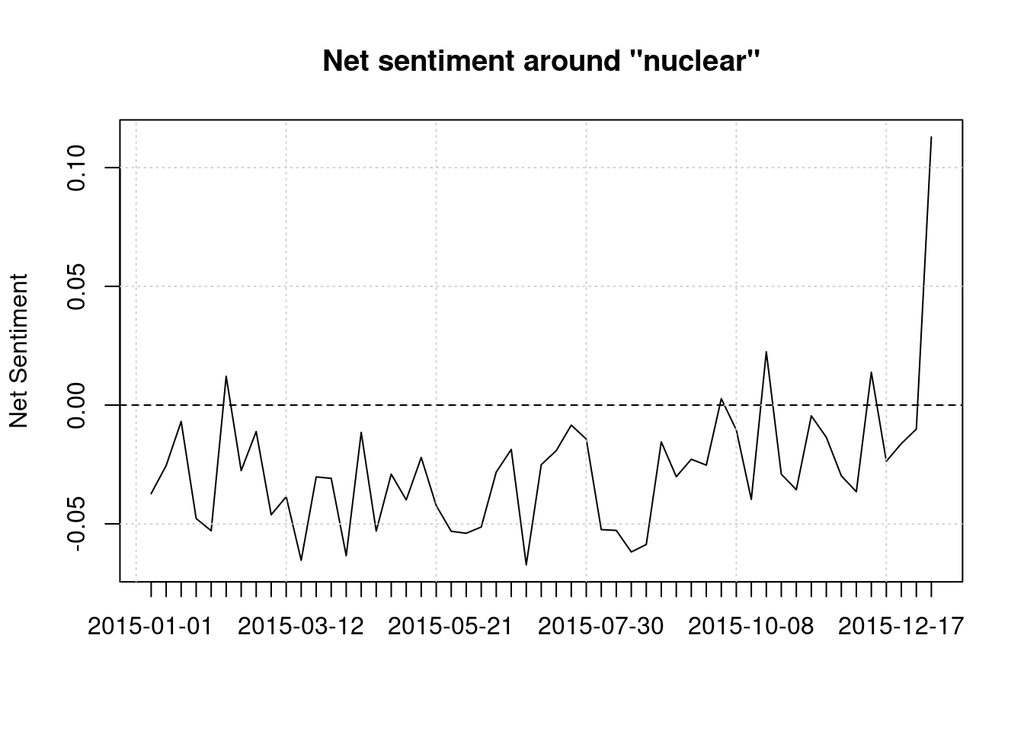

```r
toks <- tokens(corpus_kcna,
               remove_numbers = TRUE,
               remove_punct = TRUE,
               remove_symbols = TRUE,
               remove_separators = TRUE,
               remove_url = TRUE,
               include_docvars = TRUE)

toks_key <- tokens_keep(toks,
                         pattern = 'nuclear',
                         valuetype = "glob",
                         window = 15) # get window of words around keyword

toks_key <- dfm(toks_key) # create dfm of tokens object

toks_key_lsd <- toks_key %>%
  dfm_lookup(dictionary = data_dictionary_LSD2015[1:2]) %>%
  dfm_group(group = week, fill = TRUE)

# plot net sentiment
n_toks <- ntoken(dfm_group(toks_key,
                     group = docvars(toks_key, 'week'))) # get number of weekly tokens

plot((toks_key_lsd[,2] - toks_key_lsd[,1]) / n_toks,
      type = 'l', ylab = "Net Sentiment", xlab = '', main = 'Net sentiment around "nuclear"', xaxt = "n") # plot difference in share of positive and negative terms
axis(1, seq_len(ndoc(toks_key_lsd)), ymd("2015-01-01") + weeks(seq_len(ndoc(toks_key_lsd)) - 1))
grid()
abline(h = 0, lty = 2)
```

How about another term like “Japan”? We can use the same code as above but just swap “nuclear” for “japan” in the `pattern` argument for `tokens_keep`.

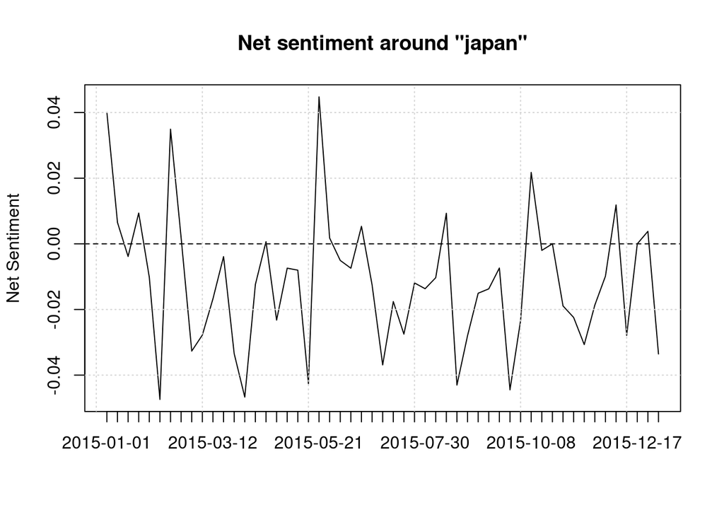

We see a consistent negative sentiment in windows that include the term “japan” over the sample time period, although there are weeks with net positive sentiment.

What about discussion surrounding “kim”?

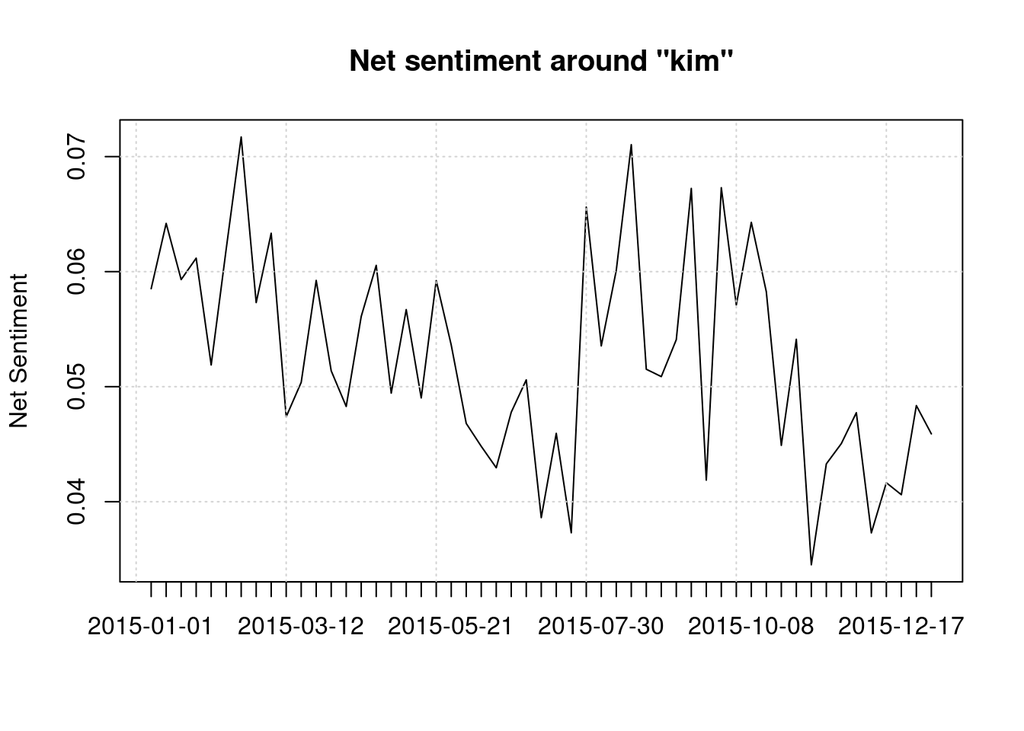

As expected, we see a very strong positive sentiment throughout the entire period.